# Midterm Project

Author

Diana Tang

Libraries

```r
library(dplyr)
library(ggplot2)
library(lubridate)
library(gridExtra)
library(knitr)
```

```r
setwd("/Users/dianalilytang/Desktop")
RSVdata <- read.csv("2023_RSV.csv")
```

```r
RSVsurv <- read.csv("RSV_Surveillance.csv")
```

## Introduction

From 2022-2023 the pediatric population was hit with a surge in respiratory syncytial virus (RSV) like never before. While previously believed to be a common virus among babies, this past winter RSV infected an increasingly large number of young children in the 0-4 age group. Children’s hospitals were now overflowing with a particularly harsh respiratory season of RSV. COVID-19, Influenza, and Human Metapneumovirus were among the many respiratory illnesses that led to a lack of beds in children’s hospitals. While children’s hospitals went surprisingly empty during most of the pandemic from COVID-19, the winter of 2022-2023 escalated to a public health disaster with shortages of oxygen and beds for children while hospitals continued to fight the surges of COVID-19 in the adult population.

To examine this finding closer, the proposed questions include: Did seasonality and patterns change in how RSV emerged in the 2022-2023 year compared to the pre-COVID-19 pandemic season of 2018-2019? Were certain pediatric age groups truly more susceptible to RSV compared to FLU or COVID in the 2022-2023 year?

### *EDA Checklist*

```r
#dim(RSVsurv)
#head(RSVsurv)
#tail(RSVsurv)
#str(RSVsurv)
```

```r
#Renaming labels for easier use and manipulation

names(RSVsurv)[names(RSVsurv)== "Surveillance.Network"] <- "SURVNET"
names(RSVsurv)[names(RSVsurv)== "Season"] <- "SN"
names(RSVsurv)[names(RSVsurv)== "MMWR.Year"] <- "YEAR"
names(RSVsurv)[names(RSVsurv)== "MMWR.Week"] <- "WEEK"
names(RSVsurv)[names(RSVsurv)== "Age.group"] <- "AGE"
names(RSVsurv)[names(RSVsurv)== "Site"] <- "SITE"
names(RSVsurv)[names(RSVsurv)== "Weekly.Rate"] <- "WKRT"
names(RSVsurv)[names(RSVsurv)== "Cumulative.Rate"] <- "CMRT"

RSVsurv2.0 <- select(RSVsurv, SURVNET, SN, YEAR, WEEK, AGE, SITE, WKRT, CMRT)
```

```r
#Finding out the unique subcategories
unique(RSVsurv2.0$AGE)
```

```
 [1] "Overall"   "12-17 yr"  "18-29 yr"  "2-4 yr"    "30-39 yr"  "40-49 yr"
 [7] "5-11 yr"   "65-74 yr"  "75-84 yr"  "85+ yr"    "0-<1 yr"   "1-4 yr"
[13] "75+ yr"    "0-4 yr"    "18-49 yr"  "5-17 yr"   "50-64 yr"  "65+ yr"
[19] "Adult"     "Pediatric"
```

```r
unique(RSVsurv2.0$SITE)
```

```
 [1] "Overall" "CA"      "CO"      "CT"      "GA"      "IA"      "MD"
 [8] "MI"      "MN"      "NM"      "NY"      "OH"      "OR"      "TN"
[15] "UT"
```

```r
unique(RSVsurv2.0$SN)
```

```
[1] 1819 1920 2122 2223 2021
```

```r
#Filtering dataset to only contain 2018-2019 pre-pandemic season and the 2022-2023 season
RSVsurv3.0 <- RSVsurv2.0 %>% filter(SN == 1819 | SN == 2223 )
```

```r
#Keeping certain age groups
RSVsurv3.0 <- RSVsurv3.0 %>% filter(AGE == "Pediatric" | AGE == "0-<1 yr" | AGE == "1-4 yr" | AGE == "5-11 yr" | AGE == "12-17 yr")
```

```r
#Summary overview
summary(RSVsurv3.0)
```

```
   SURVNET                SN            YEAR           WEEK
 Length:1317        Min.   :1819   Min.   :2018   Min.   : 1.00
 Class :character   1st Qu.:1819   1st Qu.:2019   1st Qu.:10.00
 Mode  :character   Median :2223   Median :2022   Median :23.00
                    Mean   :2090   Mean   :2021   Mean   :25.74
                    3rd Qu.:2223   3rd Qu.:2023   3rd Qu.:43.00
                    Max.   :2223   Max.   :2023   Max.   :52.00

     AGE                SITE                WKRT              CMRT
 Length:1317        Length:1317        Min.   :  0.000   Min.   :   0.0
 Class :character   Class :character   1st Qu.:  0.200   1st Qu.:  10.5
 Mode  :character   Mode  :character   Median :  0.800   Median :  36.0
                                       Mean   :  5.730   Mean   : 204.0
                                       3rd Qu.:  3.075   3rd Qu.: 113.8
                                       Max.   :194.200   Max.   :2040.0
                                       NA's   :155       NA's   :155
```

```r
#Inspecting the variables to closer details
table(RSVsurv3.0$SURVNET)
```

```
   Combined   COVID-NET FluSurv-NET     RSV-NET
        415         260         310         332
```

```r
table(RSVsurv3.0$AGE)
```

```
  0-<1 yr    1-4 yr  12-17 yr   5-11 yr Pediatric
      280       280       280       280       197
```

```r
table(RSVsurv3.0$SITE)
```

```
Overall
   1317
```

```r
#Inspecting the variables to closer details for any NAs
table(is.na(RSVsurv3.0))
```

```
FALSE  TRUE
10226   310
```

```r
table(is.na(RSVsurv3.0$WKRT))
```

```
FALSE  TRUE
 1162   155
```

```r
table(is.na(RSVsurv3.0$CMRT))
```

```
FALSE  TRUE
 1162   155
```

```r
#Removing combined data due to lack of recorded COVID in 1819 to amend the NAs
RSVsurv4.0 <- RSVsurv3.0 %>% filter(SURVNET == "COVID-NET" | SURVNET == "FluSurv-NET" | SURVNET == "RSV-NET")
table(is.na(RSVsurv4.0))
```

```
FALSE
 7216
```

## Methods

Data was acquired through the public Center for Disease and Control data sources specifically within the Public Health Surveillance Systems. Three population-based surveillance systems were used including COVID-NET, RSV-NET, and FluSurv-NET and combined to form RESP-NET. These surveillance systems collected laboratory confirmed hospitalization cases of RSV, COVID-19, and Flu from over 250 acute-care hospitals in 14 states. The current datasets used for this project were collected and updated to October 9th, 2023.

The tools used to explore the data were primarily taken from the dplyr library to filter and select from the initial data set. The dplyr library also allowed for the closer examination of the variables. The knitr, ggplot, and gridExtra libraries were used for visualization and further analysis of the data.

## Preliminary Results

### *Average Pediatric Weekly Rates of Hospitalizations for 2018-2019*

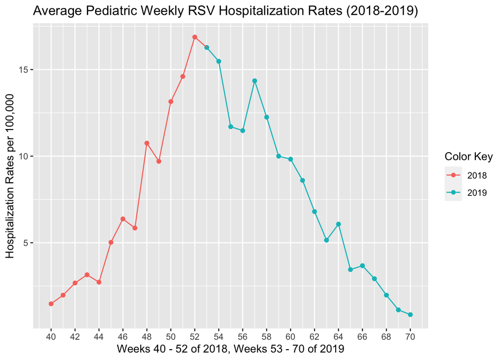

```r
#Filter dataset to RSV 2018 - 2019 data
RSV1819 <- RSVsurv4.0 %>%
  filter(SURVNET == "RSV-NET", YEAR %in% c(2018, 2019))

#Add 52 to the 2019 data to allow for chronological visualization
RSV1819 <- RSV1819 %>%
  mutate(WEEK = ifelse(YEAR == 2019, WEEK + 52, WEEK))

#Create an average weekly rate of hospitalizations from all age groups to create an average pediatric rate for the range of ages 0 - 17
RSV1819 <- RSV1819 %>%
  group_by(WEEK) %>%
  mutate(AVGWKRT = mean(WKRT, na.rm = TRUE))

#Visualize data
ggplot(data = RSV1819, aes(x = WEEK, y = AVGWKRT, color = as.factor(YEAR))) +
  geom_point() +
  labs(title = "Average Pediatric Weekly RSV Hospitalization Rates (2018-2019)", x = "Weeks 40 - 52 of 2018, Weeks 53 - 70 of 2019", y = "Hospitalization Rates per 100,000") + geom_line(aes(group = 1)) +
  scale_x_continuous(breaks = seq(40, 70, by = 2), labels = seq(40, 70, by = 2)) + guides(color = guide_legend(title = "Color Key"))
```

```r
#Peak Rates
PEAKRSV1819Y <- max(RSV1819$AVGWKRT)
PEAKRSV1819X <- RSV1819$WEEK[which.max(RSV1819$AVGWKRT)]

#Print peak values to compare to 22-23 data
PEAKRSV1819X
```

```
[1] 52
```

```r
PEAKRSV1819Y
```

```
[1] 16.875
```

### *Average Pediatric Weekly Rates of Hospitalizations for 2022-2023*

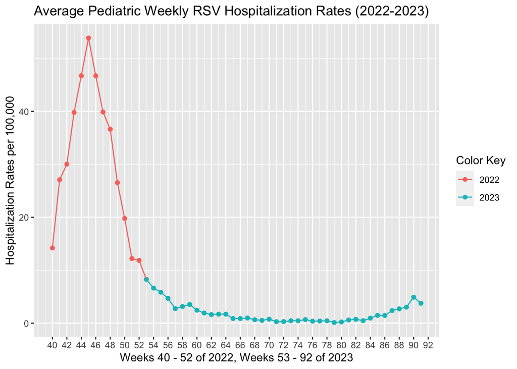

```r
#Filter dataset to RSV 2022 - 2023 data
RSV2223 <- RSVsurv4.0 %>%
  filter(SURVNET == "RSV-NET", YEAR %in% c(2022, 2023))

#Add 52 to the 2023 data to allow for chronological visualization
RSV2223 <- RSV2223 %>%
  mutate(WEEK = ifelse(YEAR == 2023, WEEK + 52, WEEK))

#Create an average weekly rate of hospitalizations from all age groups to create an average Pedaitric rate for the range of ages 0 - 17
RSV2223 <- RSV2223 %>%
  group_by(WEEK) %>%
  mutate(AVGWKRT = mean(WKRT, na.rm = TRUE))

#Visualize data
PLOT1 <- ggplot(data = RSV2223, aes(x = WEEK, y = AVGWKRT, color = as.factor(YEAR))) +
  geom_point() +
  labs(title = "Average Pediatric Weekly RSV Hospitalization Rates (2022-2023)", x = "Weeks 40 - 52 of 2022, Weeks 53 - 92 of 2023", y = "Hospitalization Rates per 100,000") + geom_line(aes(group = 1)) +
  scale_x_continuous(breaks = seq(40, 104, by = 2), labels = seq(40, 104, by = 2)) + guides(color = guide_legend(title = "Color Key"))

PLOT1
```

```r
#Peak Rates
PEAKRSV2223Y <- max(RSV2223$AVGWKRT)
PEAKRSV2223X <- RSV2223$WEEK[which.max(RSV2223$AVGWKRT)]

#Print peak values
PEAKRSV2223X
```

```
[1] 45
```

```r
PEAKRSV2223Y
```

```
[1] 53.85
```

### *RSV 2022 - 2023 by Age Group*

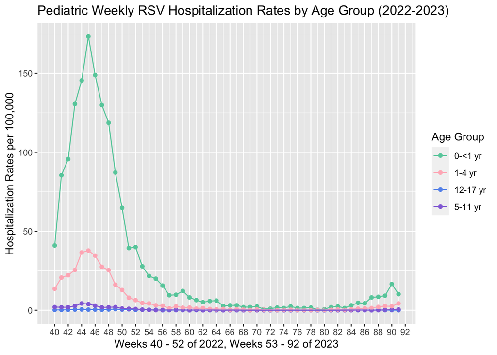

```r
ggplot(data = RSV2223, aes(x = WEEK, y = WKRT, color = AGE)) +
  geom_point() +
  labs(title = "Pediatric Weekly RSV Hospitalization Rates by Age Group (2022-2023)",
       x = "Weeks 40 - 52 of 2022, Weeks 53 - 92 of 2023",
       y = "Hospitalization Rates per 100,000") +
  scale_x_continuous(breaks = seq(40, 92, by = 2), labels = seq(40, 92, by = 2)) +
  scale_color_manual(values = c("0-<1 yr" = "mediumaquamarine", "1-4 yr" = "lightpink", "5-11 yr" = "mediumpurple", "12-17 yr" = "cornflowerblue")) +
  guides(color = guide_legend(title = "Age Group")) +
  geom_line(aes(group = AGE))
```

### *FLU 2022 to 2023 DATA*

```r
#Filter dataset to FLU 2022 - 2023 data
FLU2223 <- RSVsurv4.0 %>%
  filter(SURVNET == "FluSurv-NET", YEAR %in% c(2022, 2023))

#Add 52 to the 2023 data to allow for chronological visualization
FLU2223 <- FLU2223 %>%
  mutate(WEEK = ifelse(YEAR == 2023, WEEK + 52, WEEK))

#Create an average weekly rate of hospitalizations from all age groups to create an average Pedaitric rate for the range of ages 0 - 17
FLU2223 <- FLU2223 %>%
  group_by(WEEK) %>%
  mutate(AVGWKRT = mean(WKRT, na.rm = TRUE))

#Plot the data
PLOT2 <- ggplot(data = FLU2223, aes(x = WEEK, y = AVGWKRT, color = as.factor(YEAR))) +
  geom_point() +
  labs(title = "Average Pediatric Weekly FLU Hospitalization Rates (2022-2023)", x = "Weeks 40 - 52 of 2022, Weeks 53 - 92 of 2023", y = "Hospitalization Rates") + geom_line(aes(group = 1)) +
  scale_x_continuous(breaks = seq(40, 104, by = 2), labels = seq(40, 104, by = 2)) + guides(color = guide_legend(title = "Color Key"))
```

### *COVID-19 2022 to 2023 DATA*

```r
#Filter dataset to COVID 2022 - 2023 data
COVID2223 <- RSVsurv4.0 %>%
  filter(SURVNET == "COVID-NET", YEAR %in% c(2022, 2023))

#Add 52 to the 2023 data to allow for chronological visualization
COVID2223 <- COVID2223 %>%
  mutate(WEEK = ifelse(YEAR == 2023, WEEK + 52, WEEK))

#Create an average weekly rate of hospitalizations from all age groups to create an average Pedaitric rate for the range of ages 0 - 17
COVID2223 <- COVID2223 %>%
  group_by(WEEK) %>%
  mutate(AVGWKRT = mean(WKRT, na.rm = TRUE))

#Plot the data
PLOT3 <- ggplot(data = COVID2223, aes(x = WEEK, y = AVGWKRT, color = as.factor(YEAR))) +
  geom_point() +
  labs(title = "Average Pediatric Weekly COVID-19 Hospitalization Rates (2022-2023)", x = "Weeks 40 - 52 of 2022, Weeks 53 - 92 of 2023", y = "Hospitalization Rates") + geom_line(aes(group = 1)) +
  scale_x_continuous(breaks = seq(40, 104, by = 2), labels = seq(40, 104, by = 2)) + guides(color = guide_legend(title = "Color Key"))
```

*Adjusting Y-Axis Labels*

```r
PLOT1a <- ggplot(data = RSV2223, aes(x = WEEK, y = AVGWKRT, color = as.factor(YEAR))) +
  geom_point() +
  labs(title = "Average Pediatric Weekly RSV Hospitalization Rates (2022-2023)", x = "Weeks 40 - 52 of 2022, Weeks 53 - 92 of 2023", y = "Hospitalization Rates") + geom_line(aes(group = 1)) +
  scale_x_continuous(breaks = seq(40, 104, by = 2), labels = seq(40, 104, by = 2)) + guides(color = guide_legend(title = "Color Key"))
```

### *Comparing FLU, RSV, and COVID-19 Pediatric Averages*

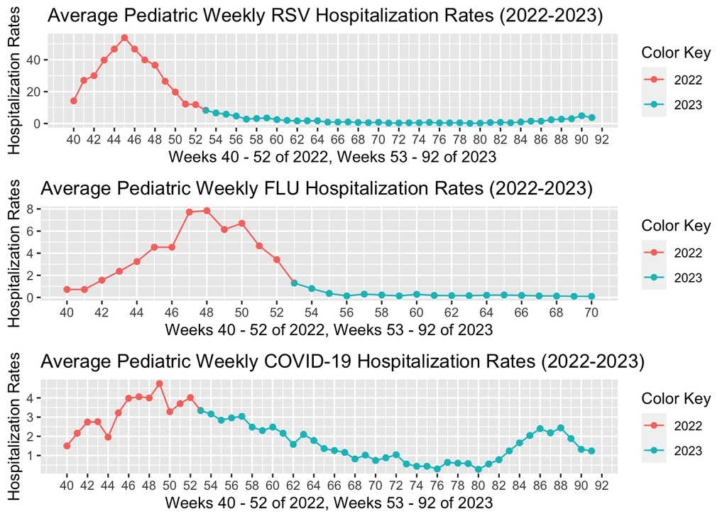

```r
grid.arrange(PLOT1a, PLOT2, PLOT3, ncol =1)
```

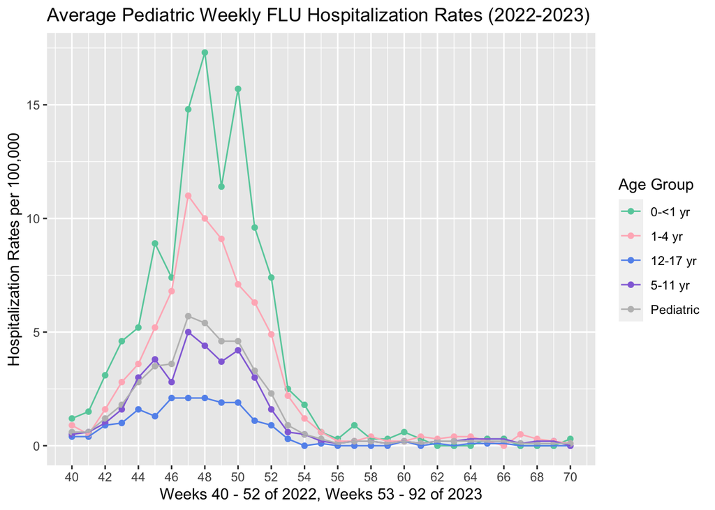

```r
ggplot(data = FLU2223, aes(x = WEEK, y = WKRT, color = AGE)) +
  geom_point() +
  labs(title = "Average Pediatric Weekly FLU Hospitalization Rates (2022-2023)",
       x = "Weeks 40 - 52 of 2022, Weeks 53 - 92 of 2023",
       y = "Hospitalization Rates per 100,000") +
  scale_x_continuous(breaks = seq(40, 92, by = 2), labels = seq(40, 92, by = 2)) +
  scale_color_manual(values = c("0-<1 yr" = "mediumaquamarine", "1-4 yr" = "lightpink", "5-11 yr" = "mediumpurple", "12-17 yr" = "cornflowerblue", "Pediatric" = "gray")) +
  guides(color = guide_legend(title = "Age Group")) +
  geom_line(aes(group = AGE))
```

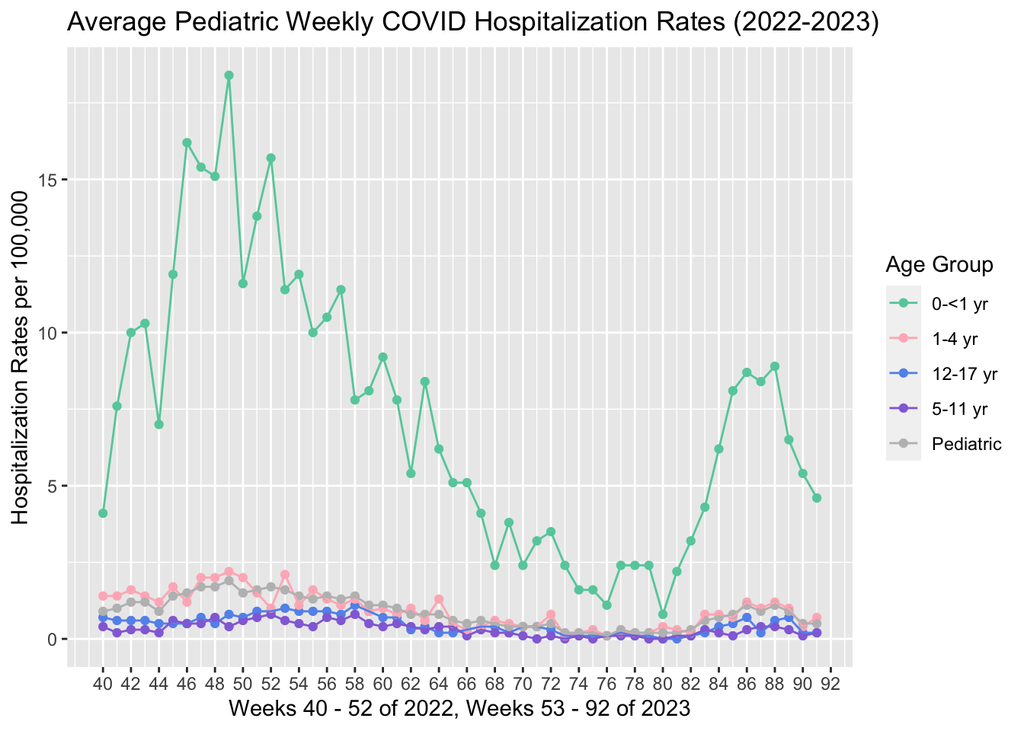

```r
ggplot(data = COVID2223, aes(x = WEEK, y = WKRT, color = AGE)) +
  geom_point() +
  labs(title = "Average Pediatric Weekly COVID Hospitalization Rates (2022-2023)",
       x = "Weeks 40 - 52 of 2022, Weeks 53 - 92 of 2023",
       y = "Hospitalization Rates per 100,000") +
  scale_x_continuous(breaks = seq(40, 92, by = 2), labels = seq(40, 92, by = 2)) +
  scale_color_manual(values = c("0-<1 yr" = "mediumaquamarine", "1-4 yr" = "lightpink", "5-11 yr" = "mediumpurple", "12-17 yr" = "cornflowerblue", "Pediatric" = "gray")) +
  guides(color = guide_legend(title = "Age Group")) +
  geom_line(aes(group = AGE))
```

### *Age 0 - <1 Hospitalization Rates 2022 - 2023*

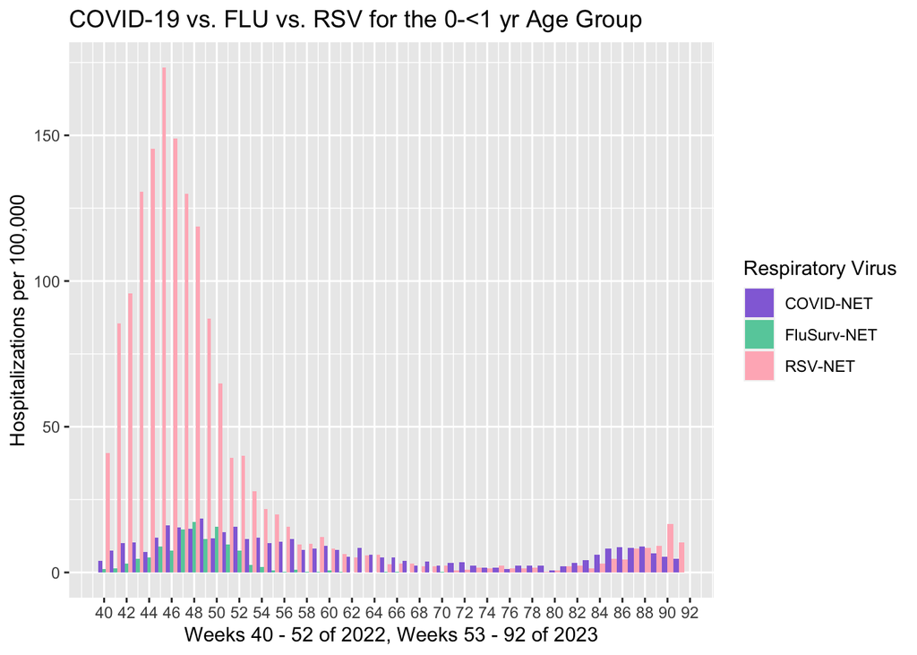

```r
#Filter the RSV SURV dataset to just the 0-<1 yr age group for the 2022-2023 season
BABIES2223 <- RSVsurv4.0 %>%
  filter(AGE == "0-<1 yr", YEAR %in% c(2022, 2023))

#Add 52 to the 2023 data to allow for chronological visualization
BABIES2223 <- BABIES2223 %>%
  mutate(WEEK = ifelse(YEAR == 2023, WEEK + 52, WEEK))

BABIES2223BARPLOT <- ggplot(data = BABIES2223, aes(x = WEEK, y = WKRT, fill = SURVNET)) +
  geom_bar(stat = "identity", position = "dodge", width = 1) +
  labs(title = "COVID-19 vs. FLU vs. RSV for the 0-<1 yr Age Group",
       x = "Weeks 40 - 52 of 2022, Weeks 53 - 92 of 2023",
       y = "Hospitalizations per 100,000") +
  scale_x_continuous(breaks = seq(40, 92, by = 2), labels = seq(40, 92, by = 2)) +
  scale_fill_manual(values = c("FluSurv-NET" = "mediumaquamarine", "RSV-NET" = "lightpink", "COVID-NET" = "mediumpurple")) +
  guides(fill = guide_legend(title = "Respiratory Virus"))

BABIES2223BARPLOT
```

### *RSV 2022 - 2023 Boxplot Visualization Age Group 0 - < 1 yr*

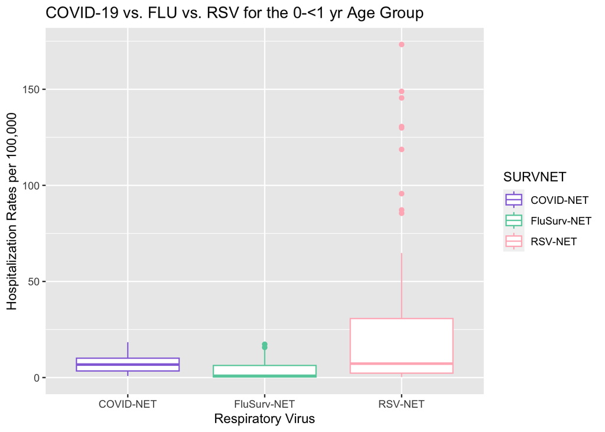

```r
ggplot(BABIES2223, aes(x = SURVNET, y = WKRT, color = SURVNET)) +
  geom_boxplot() +
  labs(title = "COVID-19 vs. FLU vs. RSV for the 0-<1 yr Age Group",
       x = "Respiratory Virus",
       y = "Hospitalization Rates per 100,000") +
  scale_color_manual(values = c("FluSurv-NET" = "mediumaquamarine", "RSV-NET" = "lightpink", "COVID-NET" = "mediumpurple"))
```

## Statistical Summary Tables

### *2022 - 2023 Weekly RSV Hospitalization Rate Summaries*

```r
RSV2223SUMMARY <- RSV2223 %>%
  group_by(AGE) %>%
  summarise(
    Mean = mean(WKRT, na.rm = TRUE),
    Median = median(WKRT, na.rm = TRUE),
    SD = sd(WKRT, na.rm = TRUE),
    Min = min(WKRT, na.rm = TRUE),
    Max = max(WKRT, na.rm = TRUE)
  )
kable(RSV2223SUMMARY, format = "html")
```

| AGE | Mean | Median | SD | Min | Max |
| --- | --- | --- | --- | --- | --- |
| 0-<1 yr | 29.7538462 | 7.25 | 46.7816223 | 0.3 | 173.3 |
| 1-4 yr | 6.4461538 | 1.30 | 10.4889944 | 0.1 | 37.8 |
| 12-17 yr | 0.1384615 | 0.10 | 0.1794915 | 0.0 | 0.7 |
| 5-11 yr | 0.6057692 | 0.10 | 1.0475767 | 0.0 | 4.3 |

### *2022 - 2023 COVID vs. FLU vs. RSV Hospitalization Rate Summaries*

```r
BABIES2223SUMMARY <- BABIES2223 %>%
  group_by(SURVNET) %>%
  summarise(
    Mean = mean(WKRT, na.rm = TRUE),
    Median = median(WKRT, na.rm = TRUE),
    SD = sd(WKRT, na.rm = TRUE),
    Min = min(WKRT, na.rm = TRUE),
    Max = max(WKRT, na.rm = TRUE)
  )
kable(BABIES2223SUMMARY, format = "html")
```

| SURVNET | Mean | Median | SD | Min | Max |
| --- | --- | --- | --- | --- | --- |
| COVID-NET | 7.230769 | 6.75 | 4.461097 | 0.8 | 18.4 |
| FluSurv-NET | 3.761290 | 0.90 | 5.196966 | 0.0 | 17.3 |
| RSV-NET | 29.753846 | 7.25 | 46.781622 | 0.3 | 173.3 |

## Conclusion

This showed that the rise of cases began even prior to November and potentially with the return to school in the September months. Cases may have began to exponentially rise as more students and caretakers were returning to in-person activities as mask-mandates began to relax during this time. While seasonality may now be shifted, questions continue to be proposed if children’s hospitals are equipped for another RSV surge. Of further interest would be further analysis that may look into how pandemic precautions and non-medical interventions of staying at home and masking may have contributed to the lack of RSV immunity communities have normally seen prior to the pandemic.

With respect to the second question proposed, the preliminary results showed that hospitalizations rates for the respiratory viruses under surveillance disproportionately affected the the 0 - < 1 age group. Visually, RSV and COVID-19 hospitalizations were dominated by the 0 - <1 age group. The FLU surveillance showed more broad hospitalizations among all age groups. However, once the data of COVID-19, FLU, and RSV were placed next to each other, it was clear that RSV remained the major infection amongst the hospitalizations for the 2022 - 2023. While no concrete treatment exists for RSV apart from oxygen support, the push to study and find quicker solutions to minimize RSV hospitalizations and hospitalization lengths of stay continues. As this data has shown how the COVID-19 pandemic continues to influence and change how we understand previous and current diseases processes such as RSV in the pediatric population.